# Tutorial 8: Data Mining Basics

Tay Xinyu, Zandra. A0239429U

Due by 1 April 2022, 8:00 AM

## Submission Instructions

- Select `output: html_document`.
- Include all code chunks, so include `echo=TRUE` in all chunks.
- Replace the placeholder text, “Type your answer here.”, with your own.
- Submit *only* the required question for grading (Part 2: Submission). You can delete everything else for that submission. Remember to include any `library('package_name')` statements that you’ll need to run your code and future reproduction.
- Rename your R Markdown file `T[X]_[MatricNumber].rmd`, and the output will automatically be `T[X]_[MatricNumber].html`.
- Submit your both R Markdown file (.rmd) and HTML (.html) to Luminus for tutorial assignments (upload to Luminus under the correct Submission Folder). We shall do the same for practical exam.
- **It is important to be able to code and produce your Rmarkdown output file *independently*.** You are responsible for de-bugging and programming in the practical exam.

```r
# load required packages
library(dplyr)
library(tidyr)
library(car) # for linearHypothesis()
library(ggplot2) # optional. we expect you to know base graphics, but allow ggplot if you find it easier
library(psych) # for pairs.panels()
# install.packages("factoextra")
library(factoextra) # for fviz_cluster()
library(wooldridge)
library(caret)
```

## Part Two: Assignment Submission

### Question 2 (total 15 points)

- Dataset required: `attend` (wooldridge)

In this question, we will be doing a model selection, principal component analysis, building a simple logit classifier, and finally assessing the output of that classifier for class performance.

The dataset for this question is available at: https://rdrr.io/cran/wooldridge/man/attend.html. a public available dataset about class attendance and final/GPA performance. Again, you need to install and load package `wooldridge` to conveniently load the data into your R workplace.

```r
data('attend')
```

Here are the variables in the dataset:

- `attend`: classes attended out of 32.
- `termGPA`: GPA for current term.
- `priGPA`: cumulative GPA prior to current term.
- `ACT`: ACT score.
- `final`: final test score.
- `atndrte`: percentage of class attendance, i.e. `attend` divided by `32`.
- `hwrte`: percentage of homework turned in.
- `frosh`: freshmen if = 1.
- `soph`: sophomore if = 1.
- `missed`: number of classes missed, i.e. `attend` + `missed` = 32.
- `stndfnl`: standardized final test score, i.e. (`final`-mean)/sd.

In the code below I make a new variable `pass` (pass the exam) which is one if student’s final performance belongs to upper 40% of class comparable to his/her peers (curved) based on the standardized final test score, i.e. `stndfnl` is greater than 60th-quantile of `stndfnl`, This would be a binary dependent variable we shall use.

In this question, we will be interested in using the independent variables (student’s class attendance) to classify the sample into whether student will pass or not.

Here are what the independent variables look like (using the `pairs.panels()` function from the `psych` package)

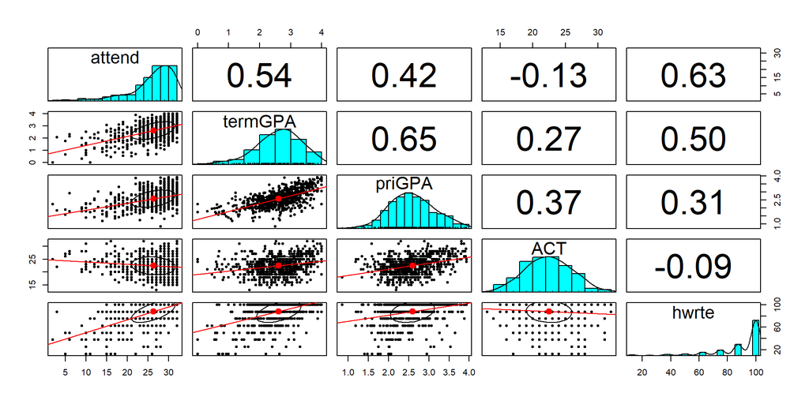

```r
# create a binary variable 'pass',
attend$pass = ifelse(attend$stndfnl > quantile(attend$stndfnl, 0.6), 1, 0)
# removing NA's in the data, just to avoid some programming issues later. WARNING: don't simply do this in your future projects.
attend = attend[complete.cases(attend),]
# Selecting out the independent variables "X".
attendX = attend %>% select(c("attend", "termGPA", "priGPA", "ACT", "hwrte"))
psych::pairs.panels(attendX, lm=TRUE)
```

(Q2a) Let’s first start with our “kitchen sink” regression model `stndfnl ~ attend + termGPA + priGPA + ACT + hwrte + frosh + soph` with entire data set `attend`. (1) using `linearHypothesis()` to jointly test if `termGPA = priGPA = ACT = 0`, i.e. current and previous GPA/test scores do not affect the final test score, and draw your conclusion for the test; (2) run a automated backward model selection using `step()` function and interpret the coefficient of `attend`. (4 points)

```r
# type your code here
lm1 <- lm(stndfnl ~ attend + termGPA + priGPA + ACT + hwrte + frosh + soph, data = `attend`)
# (1)
# viewing coefficients
coef(lm1)
```

```
##  (Intercept)       attend      termGPA       priGPA          ACT        hwrte
## -2.411394469 -0.014612419  0.744014120 -0.008716723  0.057380963 -0.002929603
##        frosh         soph
## -0.128802137 -0.172795389
```

```r
# building the hypothesis matrix from coefficients
# testing termGPA first
hyp1 <- c(0, 0, 1, 0, 0, 0, 0, 0)
rhs1 <- c(0)
linearHypothesis(lm1, hyp1, rhs1)
```

```
## Linear hypothesis test
##
## Hypothesis:
## termGPA = 0
##
## Model 1: restricted model
## Model 2: stndfnl ~ attend + termGPA + priGPA + ACT + hwrte + frosh + soph
##
##   Res.Df    RSS Df Sum of Sq      F    Pr(>F)
## 1    667 523.18
## 2    666 439.46  1    83.717 126.87 < 2.2e-16 ***
## ---
## Signif. codes:  0 '***' 0.001 '**' 0.01 '*' 0.05 '.' 0.1 ' ' 1
```

```r
# testing priGPA
hyp2 <- c(0, 0, 0, 1, 0, 0, 0, 0)
rhs2 <- c(0)
linearHypothesis(lm1, hyp2, rhs2)
```

```
## Linear hypothesis test
##
## Hypothesis:
## priGPA = 0
##
## Model 1: restricted model
## Model 2: stndfnl ~ attend + termGPA + priGPA + ACT + hwrte + frosh + soph
##
##   Res.Df    RSS Df Sum of Sq      F Pr(>F)
## 1    667 439.47
## 2    666 439.46  1 0.0069936 0.0106  0.918
```

```r
# testing ACT
hyp3 <- c(0, 0, 0, 0, 1, 0, 0, 0)
rhs3 <- c(0)
linearHypothesis(lm1, hyp3, rhs3)
```

```
## Linear hypothesis test
##
## Hypothesis:
## ACT = 0
##
## Model 1: restricted model
## Model 2: stndfnl ~ attend + termGPA + priGPA + ACT + hwrte + frosh + soph
##
##   Res.Df    RSS Df Sum of Sq      F    Pr(>F)
## 1    667 458.91
## 2    666 439.46  1    19.449 29.475 7.942e-08 ***
## ---
## Signif. codes:  0 '***' 0.001 '**' 0.01 '*' 0.05 '.' 0.1 ' ' 1
```